```python
# import packages
# Data Manipulation
import pandas as pd
import numpy as np

# To plot the graphs
import matplotlib.pyplot as plt
import seaborn as sns
from matplotlib.pyplot import figure

# Import Random Forest Classifier
from sklearn.ensemble import RandomForestClassifier

# Classification report and accuracy score
from sklearn.metrics import classification_report
from sklearn.metrics import accuracy_score

# Import warnings and add a filter to ignore them
import warnings
warnings.simplefilter('ignore')

# Import XGBoost
import xgboost

# XGBoost Classifier
from xgboost import XGBClassifier

# Confusion matrix
from sklearn.metrics import confusion_matrix

# Cross validation
from sklearn.model_selection import KFold
from sklearn.model_selection import cross_val_score

# Pandas datareader to get the data
from pandas_datareader import data

from sklearn.linear_model import LinearRegression
from sklearn.metrics import confusion_matrix, accuracy_score

from sklearn import metrics
```

# Data Collection

Since we are going to sacrifice some dataset during training the data, we are going to collect the relevant gold price and bitcoin price from the same source as given in the problem.

For Gold, we collected the price from 2016-1-1 to 2016-10-1 `Source: London Bullion Market Association.`

For Bitcoin, we collected the price also from 2016-1-1 to 2016-10-1 `Source: NASDAQ`

```python
# Gold (From our collection)
df_gold_prev = pd.read_excel('lbma_gold_pm.xlsx', header = 1)
df_gold_prev = df_gold_prev.rename({'PM': 'gold'}, axis = 1)
df_gold_prev = df_gold_prev.rename({'DATE': 'Date'}, axis = 1)
df_gold_prev['Date'] = pd.to_datetime(df_gold_prev['Date'])
df_gold_prev = df_gold_prev.iloc[15:, :]
df_gold_prev
```

|  | Date | gold |
| --- | --- | --- |
| 15 | 2016-09-09 | 1330.85 |
| 16 | 2016-09-08 | 1343.40 |
| 17 | 2016-09-07 | 1348.35 |
| 18 | 2016-09-06 | 1337.25 |
| 19 | 2016-09-05 | 1326.35 |
| ... | ... | ... |
| 185 | 2016-01-08 | 1101.85 |
| 186 | 2016-01-07 | 1106.35 |
| 187 | 2016-01-06 | 1091.40 |
| 188 | 2016-01-05 | 1077.00 |
| 189 | 2016-01-04 | 1082.25 |

175 rows × 2 columns

```python
# Open Gold dataset and merge with the previous one
df_gold = pd.read_csv('LBMA-GOLD.csv')
df_gold = df_gold.rename({'USD (PM)': 'gold'}, axis = 1)
df_gold['Date'] = pd.to_datetime(df_gold['Date'])
df_gold.head()
```

|  | Date | gold |
| --- | --- | --- |
| 0 | 2016-09-12 | 1324.60 |
| 1 | 2016-09-13 | 1323.65 |
| 2 | 2016-09-14 | 1321.75 |
| 3 | 2016-09-15 | 1310.80 |
| 4 | 2016-09-16 | 1308.35 |

```python
# Merge two dataframes
df_gold = pd.concat([df_gold_prev, df_gold])
df_gold
```

|  | Date | gold |
| --- | --- | --- |
| 15 | 2016-09-09 | 1330.85 |
| 16 | 2016-09-08 | 1343.40 |
| 17 | 2016-09-07 | 1348.35 |
| 18 | 2016-09-06 | 1337.25 |
| 19 | 2016-09-05 | 1326.35 |
| ... | ... | ... |
| 1260 | 2021-09-06 | 1821.60 |
| 1261 | 2021-09-07 | 1802.15 |
| 1262 | 2021-09-08 | 1786.00 |
| 1263 | 2021-09-09 | 1788.25 |
| 1264 | 2021-09-10 | 1794.60 |

1440 rows × 2 columns

```python
# Bitcoin (From our collection)
df_bit_prev = pd.read_csv('BTC-USD.csv')
df_bit_prev = df_bit_prev.rename({'Adj Close': 'bit'}, axis = 1)
df_bit_prev = df_bit_prev[['Date', 'bit']]
df_bit_prev['Date'] = pd.to_datetime(df_bit_prev['Date'])
df_bit_prev.head()
```

|  | Date | bit |
| --- | --- | --- |
| 0 | 2016-01-01 | 434.334015 |
| 1 | 2016-01-02 | 433.437988 |
| 2 | 2016-01-03 | 430.010986 |
| 3 | 2016-01-04 | 433.091003 |
| 4 | 2016-01-05 | 431.959991 |

```python
#Open Bitcoin dataset and merge with the previous one
df_bit = pd.read_csv('BCHAIN-MKPRU.csv')
df_bit = df_bit.rename({'Value': 'bit'}, axis = 1)
df_bit['Date'] = pd.to_datetime(df_bit['Date'])
df_bit.head()
```

|  | Date | bit |
| --- | --- | --- |
| 0 | 2016-09-11 | 621.65 |
| 1 | 2016-09-12 | 609.67 |
| 2 | 2016-09-13 | 610.92 |
| 3 | 2016-09-14 | 608.82 |
| 4 | 2016-09-15 | 610.38 |

```python
# Merge two dataframes
df_bit = pd.concat([df_bit_prev, df_bit])
```

```python
df_bit
```

|  | Date | bit |
| --- | --- | --- |
| 0 | 2016-01-01 | 434.334015 |
| 1 | 2016-01-02 | 433.437988 |
| 2 | 2016-01-03 | 430.010986 |
| 3 | 2016-01-04 | 433.091003 |
| 4 | 2016-01-05 | 431.959991 |
| ... | ... | ... |
| 1821 | 2021-09-06 | 51769.060000 |
| 1822 | 2021-09-07 | 52677.400000 |
| 1823 | 2021-09-08 | 46809.170000 |
| 1824 | 2021-09-09 | 46078.380000 |
| 1825 | 2021-09-10 | 46368.690000 |

2080 rows × 2 columns

```python
# Merge two datasets into one
df = pd.merge(df_bit,df_gold, how='left')
df.dropna(inplace = True)
df.head()
```

|  | Date | bit | gold |
| --- | --- | --- | --- |
| 3 | 2016-01-04 | 433.091003 | 1082.25 |
| 4 | 2016-01-05 | 431.959991 | 1077.00 |
| 5 | 2016-01-06 | 429.105011 | 1091.40 |
| 6 | 2016-01-07 | 458.048004 | 1106.35 |
| 7 | 2016-01-08 | 453.230011 | 1101.85 |

# Regressors

For this dataset, since we only have the price for the data, we are going to use the rolling window with different days and of different statistical features as our predictors. Specifically, we firstly compute the return of each day, and then compute the other features.

```python
# feature engineering
# return of each day
df['pct_change_gold'] = df['gold'].pct_change()
df['pct_change_bit'] = df['bit'].pct_change()

# feature 1: 5-day rolling window of standard deviation of return
df['std_5_gold'] = df['pct_change_gold'].rolling(5).std()
df['std_5_bit'] = df['pct_change_bit'].rolling(5).std()

# feature 2: 30-day rolling window of standard deviation of return
df['std_30_gold'] = df['pct_change_gold'].rolling(30).std()
df['std_30_bit'] = df['pct_change_bit'].rolling(30).std()

# feature 3: 5-day rolling window of mean of return
df['ret_5_gold'] = df['pct_change_gold'].rolling(5).mean()
df['ret_5_bit'] = df['pct_change_bit'].rolling(5).mean()

# feature 4: 30-day rolling window of mean of return
df['ret_30_gold'] = df['pct_change_gold'].rolling(30).mean()
df['ret_30_bit'] = df['pct_change_bit'].rolling(30).mean()

df = df.dropna()
```

```python
df.head()
```

[output not shown]

```python
# Defining the input and output variable
# X is the input variable, where includes all the features we constructed above
X_bit = df[['std_5_bit','ret_5_bit', 'std_30_bit','ret_30_bit']]
X_gold = df[['std_5_gold', 'ret_5_gold', 'std_30_gold', 'ret_30_gold']]

# y is the output variable; which equal to the return of gold or bitcoin
y_gold = df['pct_change_gold']
y_bit = df['pct_change_bit']
```

# Trian-test split

We now split the dataset into 75% Training dataset and 25% for Testing dataset.

```python
# Total dataset length
dataset_length = df.shape[0]

# Training dataset length
split = int(dataset_length * 0.75)
split
```

```
1046
```

```python
# Splitiing the X and y into train and test datasets
# gold
X_train_gold, X_test_gold = X_gold[:split], X_gold[split:]
y_train_gold, y_test_gold = y_gold[:split], y_gold[split:]

# bit
X_train_bit, X_test_bit = X_bit[:split], X_bit[split:]
y_train_bit, y_test_bit = y_bit[:split], y_bit[split:]
```

# Linear Regression

## Gold

```python
regression_gold = LinearRegression()
regression_gold.fit(X_train_gold, y_train_gold)
print("regression coefficient",regression_gold.coef_)
print("regression intercept",regression_gold.intercept_)
```

```
regression coefficient [ 1.36822837e-02  9.57434312e-01 -1.06195522e-03 -6.46940147e-04]
regression intercept -8.164085454269752e-05
```

```python
# the coefficient of determination R²
regression_confidence = regression_gold.score(X_test_gold, y_test_gold)
print("linear regression confidence: ", regression_confidence)
```

```
linear regression confidence:  0.13988702970766775
```

## Bitcoin

```python
regression_bit = LinearRegression()
regression_bit.fit(X_train_bit, y_train_bit)
print("regression coefficient",regression_bit.coef_)
print("regression intercept",regression_bit.intercept_)
```

```
regression coefficient [ 0.0949629   1.0164943  -0.079751   -0.02546021]
regression intercept -0.00019686331059978615
```

```python
# the coefficient of determination R²
regression_confidence = regression_bit.score(X_test_bit, y_test_bit)
print("linear regression confidence: ", regression_confidence)
```

```
linear regression confidence:  0.24207040697830673
```

## Measurement of Errors

```python
pred_gold = regression_gold.predict(X_test_gold)
print('Mean Absolute Error (MAE) of gold:', metrics.mean_absolute_error(y_test_gold, pred_gold))

pred_bit = regression_bit.predict(X_test_bit)
print('Mean Absolute Error (MAE) of bitcoin:', metrics.mean_absolute_error(y_test_bit, pred_bit))
```

```
Mean Absolute Error (MAE) of gold: 0.0071204264703493845
Mean Absolute Error (MAE) of bitcoin: 0.02964837818427082
```

```python
print('Mean Squared Error (MSE) of gold:', metrics.mean_squared_error(y_test_gold, pred_gold))
print('Mean Squared Error (MSE) of bitcoin:', metrics.mean_squared_error(y_test_bit, pred_bit))
```

```
Mean Squared Error (MSE) of gold: 9.028147064758969e-05
Mean Squared Error (MSE) of bitcoin: 0.0015951419939389663
```

```python
print('Root Mean Squared Error (RMSE) of gold:', np.sqrt(metrics.mean_squared_error(y_test_gold, pred_gold)))
print('Root Mean Squared Error (RMSE) of bitcoin:', np.sqrt(metrics.mean_squared_error(y_test_bit, pred_bit)))
```

```
Root Mean Squared Error (RMSE) of gold: 0.009501656205503844
Root Mean Squared Error (RMSE) of bitcoin: 0.03993922875994185
```

## Prediction

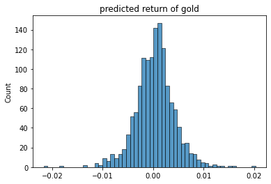

```python
sns.histplot(regression_gold.predict(X_gold))
plt.title('predicted return of gold')
```

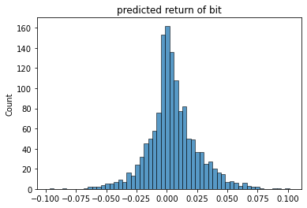

```python
sns.histplot(regression_gold.predict(X_bit))
plt.title('predicted return of bit')
```

```python
df_pred = pd.DataFrame({'Date': df['Date'],
                        'pred_gold': regression_gold.predict(X_gold),
                        'pred_bit': regression_bit.predict(X_bit)})
df_pred = df_pred.iloc[140:, :]
df_pred
```

|  | Date | pred_gold | pred_bit |
| --- | --- | --- | --- |
| 255 | 2016-09-12 | -0.000206 | 0.000141 |
| 256 | 2016-09-13 | -0.001938 | -0.000522 |
| 257 | 2016-09-14 | -0.003844 | -0.002061 |
| 258 | 2016-09-15 | -0.004721 | -0.005790 |
| 259 | 2016-09-16 | -0.003301 | -0.005034 |
| ... | ... | ... | ... |
| 2075 | 2021-09-06 | 0.002430 | 0.018755 |
| 2076 | 2021-09-07 | -0.001338 | 0.021957 |
| 2077 | 2021-09-08 | -0.002720 | 0.002852 |
| 2078 | 2021-09-09 | -0.002557 | -0.007852 |
| 2079 | 2021-09-10 | -0.003064 | -0.008523 |

1255 rows × 3 columns

```python
df_pred['diff'] = df_pred['pred_gold'] - df_pred['pred_bit']
df_pred = df_pred.dropna()
df_pred['decision'] = np.where(df_pred['diff'] > 0, 'Gold','Bitcoin')
df_pred
```

|  | Date | pred_gold | pred_bit | diff | decision |
| --- | --- | --- | --- | --- | --- |
| 255 | 2016-09-12 | -0.000206 | 0.000141 | -0.000348 | Bitcoin |
| 256 | 2016-09-13 | -0.001938 | -0.000522 | -0.001416 | Bitcoin |
| 257 | 2016-09-14 | -0.003844 | -0.002061 | -0.001784 | Bitcoin |
| 258 | 2016-09-15 | -0.004721 | -0.005790 | 0.001069 | Gold |
| 259 | 2016-09-16 | -0.003301 | -0.005034 | 0.001733 | Gold |
| ... | ... | ... | ... | ... | ... |
| 2075 | 2021-09-06 | 0.002430 | 0.018755 | -0.016325 | Bitcoin |
| 2076 | 2021-09-07 | -0.001338 | 0.021957 | -0.023296 | Bitcoin |
| 2077 | 2021-09-08 | -0.002720 | 0.002852 | -0.005572 | Bitcoin |
| 2078 | 2021-09-09 | -0.002557 | -0.007852 | 0.005295 | Gold |
| 2079 | 2021-09-10 | -0.003064 | -0.008523 | 0.005459 | Gold |

1255 rows × 5 columns

```python
df_pred['commission'] = np.where(df_pred['decision'].shift(1) != df_pred['decision'], 'happen', 'not happen')
df_pred
```

|  | Date | pred_gold | pred_bit | diff | decision | commission |
| --- | --- | --- | --- | --- | --- | --- |
| 255 | 2016-09-12 | -0.000206 | 0.000141 | -0.000348 | Bitcoin | happen |
| 256 | 2016-09-13 | -0.001938 | -0.000522 | -0.001416 | Bitcoin | not happen |
| 257 | 2016-09-14 | -0.003844 | -0.002061 | -0.001784 | Bitcoin | not happen |
| 258 | 2016-09-15 | -0.004721 | -0.005790 | 0.001069 | Gold | happen |
| 259 | 2016-09-16 | -0.003301 | -0.005034 | 0.001733 | Gold | not happen |
| ... | ... | ... | ... | ... | ... | ... |
| 2075 | 2021-09-06 | 0.002430 | 0.018755 | -0.016325 | Bitcoin | happen |
| 2076 | 2021-09-07 | -0.001338 | 0.021957 | -0.023296 | Bitcoin | not happen |
| 2077 | 2021-09-08 | -0.002720 | 0.002852 | -0.005572 | Bitcoin | not happen |
| 2078 | 2021-09-09 | -0.002557 | -0.007852 | 0.005295 | Gold | happen |
| 2079 | 2021-09-10 | -0.003064 | -0.008523 | 0.005459 | Gold | not happen |

1255 rows × 6 columns

Therefore, we get our final result. If we add the commission fee in our calculation, then the condition should be by bitcoin when `(return of bitcoin - alpha2) > (return of gold - alpha1)`; buy gold when `(return of bitcoin - alpha2) < (return of gold - alpha1)`

Additionaly, our return of each option will be `(return of bitcoin)` for bitcoin; `(return of gold)` for gold; when commission does not happen.

And `(return of bitcoin - alpha2)` for bitcoin; `(return of gold - alpha1)` for gold when commission happens as indicated in the dataframe.

Since the value of alpha1, alpha2 did not specify, the formal code cannot be formulated.